# Worldwide Analysis

We check the length of the datasets for worldwide confimed, recovered and fatalities and group them by country to avoid several entries per country.

```
Length of worldwide confirmed cases table: 279
Length of worldwide fatalities table: 279
Length of worldwide recovered table: 264
```

```
Length of unique country values for worldwide confirmed cases: 195
Length of unique country values for worldwide fatalities: 195
Length of unique country values for worldwide recovered: 195
```

China and South Korea are added to the list for comparison reasons as they have been the two first countries to slow down and decrease the number of active cases after an outbreak.

```
Index(['Date', 'Afghanistan confirmed',
       'Saint Vincent and the Grenadines confirmed', 'Nicaragua confirmed',
       'Niger confirmed', 'Nigeria confirmed', 'China confirmed',
       'South Korea confirmed', 'Afghanistan fatalities',
       'Saint Vincent and the Grenadines fatalities', 'Nicaragua fatalities',
       'Niger fatalities', 'Nigeria fatalities', 'China fatalities',
       'South Korea fatalities', 'Afghanistan recovered',
       'Saint Vincent and the Grenadines recovered', 'Nicaragua recovered',
       'Niger recovered', 'Nigeria recovered', 'China recovered',
       'South Korea recovered'],
      dtype='object', name='Country/Region')
```

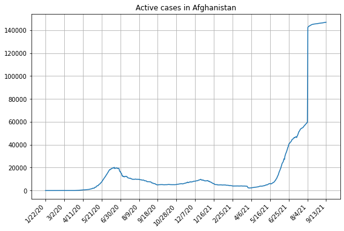

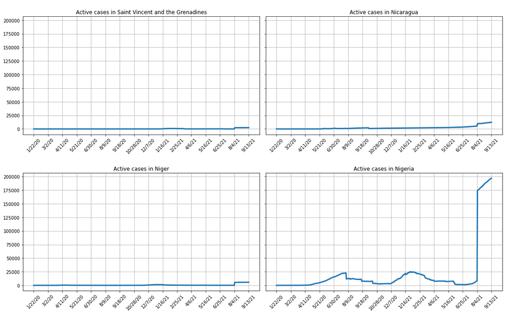

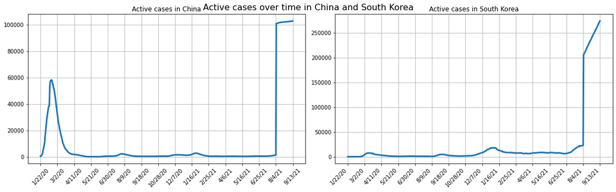

## References

[1](https://www.medrxiv.org/content/10.1101/2020.03.15.20036293v1.full.pdf) Jennifer Beam Dowd, Valentina Rotondi, Liliana Andriano, David M. Brazel, Per Block, Xuejie Ding, Yan Liu, Melinda C. Mills.  
Demographic science aids in understanding the spread and fatality rates of COVID-19. March 15, 2020

[2](https://www.faz.net/aktuell/wissen/geist-soziales/coronavirus-pandemie-warum-ist-es-in-italien-so-schlimm-16693408.html) Andreas Rossmann. Warum ist es in Italien so schlimm? Frankfurter Allgemeine Zeiting. March 23, 2020.

[3](https://de.statista.com/infografik/21211/anzahl-der-durchgefuehrten-coronavirus-tests-je-1-mio-einwohner-in-laendern-weltweit/) Frauke Suhr. So oft wird auf COVID-19 getestet. May 4, 2020.

[4](https://de.statista.com/statistik/daten/studie/1103904/umfrage/corona-infektionen-covid-19-in-deutschland-nach-altersgruppe/) Corona-Infektionen (COVID-19) in Deutschland nach Altersgruppen. May 17, 2020.